# Raw data cleanup

## Initialization

We start the analysis by initializing the packages required for all the analysis performed in this section. We also define the root directory, within which all the input/output operations for this project will be performed. At the end of this document, detailed software version information is provided for easier reproducibility of the analysis.

```r
library(reshape2)
library(ggplot2)
library(DT)
library(readxl)
library(WriteXLS)

path = "/Users/ashwin/Documents/Projects/YeastScreen/Essential_DAmP_screen/"
```

## Global plate mapping annotation

A global plate mapping template is an annotation file which defines the content of each well across the plates. This file was created and kindly provided by Manisha Wadhwa. Each plate is composed of `32 x 48` wells arranged in `4 x 4` grid consisting of redox measurements in quadruplicates from **Mitochondria, Cytoplasm, Blank and Control**. In total, this results in `1536` individual wells and `384` wells per measurement in one plate. We will read this mapping file provided by Manisha and check its integrity for -

- How the contents are named
- Number of wells assigned to each content type

The distribution of wells per assigned category in the mapping table is as below -

```r
mapPlate = data.frame(read_excel(paste0(path, "data/annotations/plateMapping_DAmP.xlsx"),
    sheet = 1))
colnames(mapPlate) = c("Well", "Content", "Group", "Well_96")
table(mapPlate$Content)
```

```
     Blank Control C1 Control C2 Control C3 Control C4  Sample X1  Sample X2
       384         96         96         96         96        384        384
```

Everything looks in order. As mentioned before we have `32 x 48 = 1536` wells per plate. Since we have quadruplicates, we should have `1536/4 = 384` values per category.

The correct naming scheme, as suggested by Manisha in our discussions, should have been as follows -

- Blank B is Blank
- Control C1-C4 is Control
- Sample X1 is Mitochondria
- Sample X2 is Cytoplasm

We visualize the counts per Category and Group. Ideally the count should be `4` since we have quadruplicates.

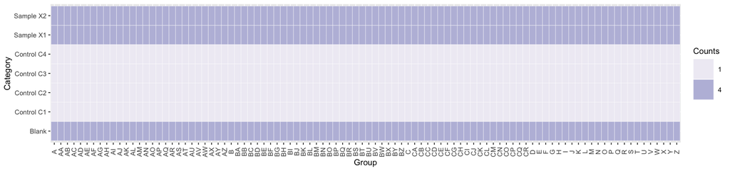

```r
# See visually the counts per Category and Group
mat = melt(table(mapPlate$Content, mapPlate$Group))
colnames(mat) = c("Category", "Group", "Counts")
mat$Counts = factor(mat$Counts)

ggplot(mat, aes(x = Group, y = Category, fill = Counts)) + theme_grey(base_size = 7) +
    geom_tile(colour = "white") + scale_fill_manual(values = c("#efedf5", "#bcbddc",
    "#807dba", "#4a1486")) + theme(axis.text.x = element_text(angle = 90, hjust = 0.5,
    vjust = 0.5))
```

We next combine the controls into one category. After this, we perform some sanity checks to see that we have the same counts all across. Also, the number of wells per categories looks correct.

```r
# Homegenizing content annotations
mapPlate$Content[mapPlate$Content == "Blank"] = "Blank"
mapPlate$Content[mapPlate$Content %in% paste0("Control C", 1:4)] = "Control"
mapPlate$Content[mapPlate$Content == "Sample X1"] = "Mitochondria"
mapPlate$Content[mapPlate$Content == "Sample X2"] = "Cytoplasm"

# Number of wells per category
table(mapPlate$Content)
```

```
       Blank      Control    Cytoplasm Mitochondria
         384          384          384          384
```

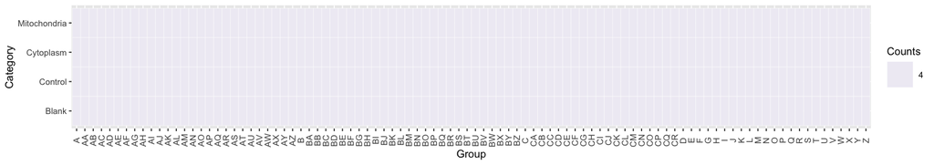

```r
# After correction, visualize the counts per Category and Group
mat = melt(table(mapPlate$Content, mapPlate$Group))
colnames(mat) = c("Category", "Group", "Counts")
mat$Counts = factor(mat$Counts)

ggplot(mat, aes(x = Group, y = Category, fill = Counts)) + theme_grey(base_size = 7) +
    geom_tile(colour = "white") + scale_fill_manual(values = c("#efedf5", "#bcbddc",
    "#807dba", "#4a1486")) + theme(axis.text.x = element_text(angle = 90, hjust = 0.5,
    vjust = 0.5))
```

## Yeast mutant gene annotations

Next, we will read the annotation file having the information on the essential yeast mutant genes and their mapping order on the plates. On this we perform some basic exploratory analysis. It has information about `788` mutants (see the number of rows in the table below).

```r
geneAnno = read.csv(paste0(path, "data/annotations/DAmP_annotation.csv"), stringsAsFactors = F)
geneAnno = geneAnno[, c(4, 5, 7, 10)]
geneAnno$SystematicName = gsub("  ", "", geneAnno$SystematicName)

ids = do.call("rbind", strsplit(geneAnno$transOMIC.PRC, " ", fixed = T))
colnames(ids) = c("Plate", "Well")
ids[, 2] = gsub("_", "", ids[, 2])
geneAnno = geneAnno[, -ncol(geneAnno)]
geneAnno = cbind(geneAnno, ids)
geneAnno$Plate = factor(as.character(geneAnno$Plate), levels = as.character(c(1:12)))

datatable(geneAnno, rownames = FALSE, filter = "top", class = "compact", extensions = c("Buttons"),
    options = list(autoWidth = TRUE, dom = "Bfrtip", buttons = c("csv", "excel",
        "print")))
```

| SystematicName | SGD.ID | Gene.Symbol | Plate | Well |
| --- | --- | --- | --- | --- |
| YAL025C | S000000023 | MAK16 | 1 | A1 |
| YBL097W | S000000193 | BRN1 | 1 | A3 |
| YCL004W | S000000510 | PGS1 | 1 | A9 |
| YDL058W |  | USO1 | 1 | A10 |
| YDL084W | S000002242 | SUB2 | 1 | A11 |
| YDL132W | S000002290 | CDC53 | 1 | A12 |
| YDL140C | S000002299 | RPO21 | 1 | B1 |
| YDR050C | S000002457 | TPI1 | 1 | B3 |
| YDR088C | S000002495 | SLU7 | 1 | B4 |
| YDR145W | S000002552 | TAF12 | 1 | B5 |

[output cut: 778 more lines]

In case of missing gene symbols, we have replaced this with the systematic name of the mutant.

```r
sum(is.na(geneAnno$Gene.Symbol))
```

```
[1] 34
```

```r
geneAnno$Gene.Symbol[is.na(geneAnno$Gene.Symbol)] = geneAnno$SystematicName[is.na(geneAnno$Gene.Symbol)]
```

Total number of unique mutant annotation (gene symbols) in the provided mutant annotation file

```r
length(unique(geneAnno$Gene.Symbol))
```

```
[1] 788
```

```r
sum(duplicated(geneAnno$Gene.Symbol))
```

```
[1] 0
```

Number of mutants per plate is visualized below

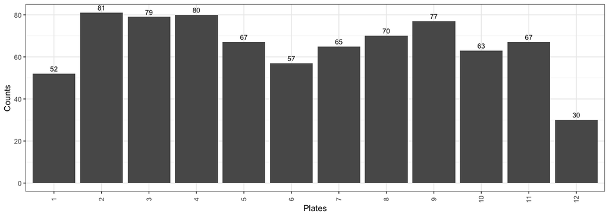

```r
dat = sapply(split(geneAnno, geneAnno$Plate), nrow)
dat = data.frame(Plates = names(dat), Counts = as.numeric(dat))
dat$Plates = factor(as.character(dat$Plates), levels = as.character(c(1:12)))

ggplot(data = dat, aes(x = Plates, y = Counts)) + theme_bw(base_size = 7) + geom_bar(stat = "identity",
    position = position_dodge()) + geom_text(aes(label = Counts), vjust = -0.5, position = position_dodge(0.9),
    size = 2) + theme(axis.text.x = element_text(angle = 90, hjust = 0.5, vjust = 0.5))
```

We then split this mutant annotation table into a list object with one slot per plate. For sanity checks, we count the number of plates and they are `12` as expected.

```r
geneAnno = split(geneAnno, geneAnno$Plate)
length(geneAnno)
```

```
[1] 12
```

## Redox screen plates naming scheme

In the previous steps, we have read only the plate annotation files (provided by Manisha) and corrected them. Now we will read actual plates with the redox values. However before compiling the values we will check the naming scheme used in each plate and make sure that this is consistent with the corrected annotation files above. All looks good. Ideally, the total count should be `7 ( i.e Blank B, Control C1-C4, Sample X1-X2 )`.

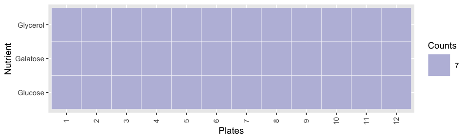

```r
classType = vector("list", 3)
names(classType) = c("glc", "gal", "gly")
for (i in names(classType)) {
    files = list.files(paste0(path, "plateReadings/", i), full.names = T)
    # files = grep('Control', files, invert = T, value = T)

    for (j in files) {
        # Extracting plate identifier
        plate = gsub(paste0("_", i, ".CSV"), "", sapply(strsplit(j, "/", fixed = T),
            function(x) x[length(x)]))

        # Raw data per plate
        tmpDat = read.csv(j, skip = 6, stringsAsFactors = F, header = T)
        tmpDat = tmpDat[, c(1:5, 9)]
        colnames(tmpDat)[2:3] = c("Content.Plate", "Group.Plate")
        classType[[i]][[plate]] = table(tmpDat$Content.Plate)

        rm(plate, tmpDat)
    }
    rm(j, files)
}

glc = melt(classType$glc)
glc = sapply(split(glc, glc$L1), nrow)

gal = melt(classType$gal)
gal = sapply(split(gal, gal$L1), nrow)

gly = melt(classType$gly)
gly = sapply(split(gly, gly$L1), nrow)

# mm = melt(classType$mm) mm = sapply(split(mm, mm$L1), nrow)

mat = data.frame(Glucose = glc, Galatose = gal, Glycerol = gly)
mat = cbind(mat, Plates = rownames(mat))
mat = suppressMessages(melt(mat))
colnames(mat) = c("Plates", "Nutrient", "Counts")
mat$Counts = factor(mat$Counts)
mat$Plates = factor(as.character(mat$Plates), levels = as.character(c(1:12)))

ggplot(mat, aes(y = Nutrient, x = Plates, fill = Counts)) + theme_grey(base_size = 7) +
    geom_tile(colour = "white") + scale_fill_manual(values = c("#bcbddc", "#807dba",
    "#4a1486")) + theme(axis.text.x = element_text(angle = 90, hjust = 0.5, vjust = 0.5))
```

## Merging of all redox screen plates

We then merge the redox values measured across the plates for all the mutants.

```r
rawDat = vector("list", 3)
names(rawDat) = c("glc", "gal", "gly")

for (i in names(rawDat)) {
    files = list.files(paste0(path, "plateReadings/", i), full.names = T)
    # files = grep('Control', files, invert = T, value = T)

    for (j in files) {
        # Extracting plate identifier
        plate = gsub(paste0("_", i, ".CSV"), "", sapply(strsplit(j, "/", fixed = T),
            function(x) x[length(x)]), fixed = T)

        # Raw data per plate
        tmpDat = read.csv(j, skip = 6, stringsAsFactors = F, header = T)
        if (i == "glc" & plate == "1") {
            tmpDat = tmpDat[, c(1:5, 9)]  # because for this file the last two columns are swapped
        } else {
            tmpDat = tmpDat[, c(1:5, 8)]
        }

        colnames(tmpDat) = c("Well", "Content.Plate", "Group.Plate", "Signal_485_520",
            "Signal_400_520", "roGFP2.ratio")
        tmpMap = mapPlate

        # Merging the raw data per plate with the above annotation
        merge.dat = merge(x = tmpDat, y = tmpMap, all = T)
        merge.dat = merge.dat[order(merge.dat$Group), ]
        merge.dat = merge.dat[, c("Well", "Well_96", "Group.Plate", "Group", "Content.Plate",
            "Content", "roGFP2.ratio", "Signal_485_520", "Signal_400_520")]

        rm(tmpDat, tmpMap)

        # Mutant annotation information per plate
        ga.tmp = geneAnno[[plate]]
        colnames(ga.tmp) = c("SystematicName", "SGD.ID", "Gene.Symbol", "Plate",
            "Well_96")

        # Merging the above merged object with mutant annotation information
        merge.dat.gen = merge(x = ga.tmp, y = merge.dat)
        merge.dat.gen = merge.dat.gen[order(merge.dat.gen$Group, merge.dat.gen$Content),
            ]
        merge.dat.gen = merge.dat.gen[, c("Plate", "Well_96", "Well", "Group", "Content",
            "SystematicName", "SGD.ID", "Gene.Symbol", "roGFP2.ratio", "Signal_485_520",
            "Signal_400_520")]

        # Save the data
        rawDat[[i]][[plate]] = merge.dat.gen
        rm(ga.tmp, merge.dat, merge.dat.gen, plate)
    }
    rm(files, j)
}
```

Next, we also merge the values across nutrient conditions and create a single composite data table for the entire screen. We perform some sanity checks on the summarized counts and perform general visualization of the data.

```r
rawDat = lapply(rawDat, function(x) do.call("rbind", x))
rawDat = rbind(cbind(rawDat$glc, Type = "Glucose"), cbind(rawDat$gal, Type = "Galactose"),
    cbind(rawDat$gly, Type = "Glycerol"))

rownames(rawDat) = 1:nrow(rawDat)

rawDat$roGFP2.ratio = suppressWarnings(as.numeric(rawDat$roGFP2.ratio))
rawDat$Well = factor(rawDat$Well)
rawDat$Group = factor(rawDat$Group)
rawDat$Content = factor(rawDat$Content, levels = c("Blank", "Control", "Cytoplasm",
    "Mitochondria"))
rawDat$Type = factor(rawDat$Type, levels = c("Glucose", "Galactose", "Glycerol"))

summary(rawDat)
```

```
     Plate          Well_96           Well           Group
 2      : 3888   A11    :  576   A41    :   36   AL     :  576
 4      : 3840   D10    :  576   A42    :   36   AT     :  576
 3      : 3792   D2     :  576   A43    :   36   K      :  576
 9      : 3696   A1     :  528   A44    :   36   A      :  528
 8      : 3360   D1     :  528   B41    :   36   AK     :  528
 5      : 3216   D5     :  528   B42    :   36   AO     :  528
 (Other):16032   (Other):34512   (Other):37608   (Other):34512
         Content     SystematicName        SGD.ID          Gene.Symbol
 Blank       :9456   Length:37824       Length:37824       Length:37824
 Control     :9456   Class :character   Class :character   Class :character
 Cytoplasm   :9456   Mode  :character   Mode  :character   Mode  :character
 Mitochondria:9456



  roGFP2.ratio    Signal_485_520   Signal_400_520          Type
 Min.   :-9.746   Min.   :  3233   Min.   : 42236   Glucose  :12608
 1st Qu.: 0.469   1st Qu.: 23950   1st Qu.: 91826   Galactose:12608
 Median : 0.568   Median : 95556   Median :122538   Glycerol :12608
 Mean   : 0.648   Mean   : 87522   Mean   :123032
 3rd Qu.: 0.817   3rd Qu.:127033   3rd Qu.:148720
 Max.   : 6.500   Max.   :260000   Max.   :260000
 NA's   :9456
```

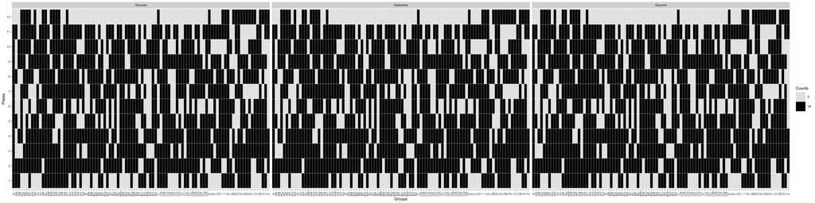

```r
vals = melt(table(rawDat$Plate, rawDat$Group, rawDat$Type))
colnames(vals) = c("Plates", "Groups", "Nutrient", "Counts")
vals$Plates = factor(vals$Plates)
vals$Counts = factor(vals$Counts)

ggplot(vals, aes(x = Groups, y = Plates, fill = Counts)) + theme_grey(base_size = 7) +
    geom_tile(colour = "white") + scale_fill_manual(values = c("grey90", "black")) +
    facet_wrap(~Nutrient) + theme(axis.text.x = element_text(angle = 90, hjust = 0.5,
    vjust = 0.5))
```

Below, we visualize a randomly 1000 rows from the compiled redox screening dataset

```r
datatable(rawDat[sample(1:nrow(rawDat), 1000), ], rownames = FALSE, filter = "top",
    class = "compact", extensions = c("Buttons"), options = list(autoWidth = TRUE,
        dom = "Bfrtip", buttons = c("csv", "excel", "print")))
```

| Plate | Well_96 | Well | Group | Content | SystematicName | SGD.ID | Gene.Symbol | roGFP2.ratio | Signal_485_520 | Signal_400_520 | Type |
| --- | --- | --- | --- | --- | --- | --- | --- | --- | --- | --- | --- |
| 7 | A5 | A20 | E | Control | YHR196W | S000001239 | UTP9 | 0.5511 | 171895 | 155434 | Glucose |
| 2 | A3 | A11 | C | Control | YKR083C | S000001791 | DAD2 | 0.604 | 160718 | 152353 | Glucose |
| 9 | B11 | F42 | W | Mitochondria | YLR310C | S000004301 | CDC25 | 0.7863 | 115161 | 155504 | Glycerol |
| 3 | H9 | e36 | CO | Cytoplasm | YDL105W |  | QRI2 | 0.6209 | 112145 | 137061 | Glycerol |
| 8 | H5 | e19 | CK | Cytoplasm | YLR117C | S000004107 | CLF1 | 0.7116 | 74008 | 123403 | Galactose |
| 8 | B1 | F04 | M | Control | YKL035W | S000001518 | UGP1 | 0.3908 | 110750 | 103703 | Glycerol |
| 12 | B2 | H07 | N | Cytoplasm | YPR104C |  | FHL1 | 0.4934 | 60482 | 81206 | Glycerol |
| 4 | B7 | G28 | S | Cytoplasm | YDL207W | S000002366 | GLE1 | 0.5986 | 83461 | 123079 | Galactose |
| 4 | E1 | Q03 | AW | Control | YDR141C | S000002548 | DOP1 | 0.3792 | 92858 | 96887 | Glycerol |
| 3 | D9 | O36 | AS | Cytoplasm | YBR234C | S000000438 | ARC40 | 0.6168 | 98092 | 119933 | Glycerol |

[output cut: 990 more lines]

## Saving the data

```r
saveRDS(rawDat, paste0(path, "data/workspaces/YeastRedox_DAmP_RawData.RDS"))
WriteXLS(rawDat, ExcelFileName = paste0(path, "analysis/supplementary/tables/YeastRedox_DAmP_RawData.xlsx"),
    AdjWidth = TRUE, BoldHeaderRow = TRUE, FreezeRow = 1)
```

Ashwini Kumar Sharma, PhD

2021-06-18